Link to Github: [marisalong.github.io](https://marisalong.github.io/)

# Analysis of Alzheimer's Disease Features

#### Marisa Long and Anna Schoeny

#### Notebook Contents

Introduction\ Discussion of Data Sources\ Dataset Vocabulary and Abbreviations\ Data Limitations\ Extract, Transform, Load (ETL)\ Exploratory Data Analysis (EDA)\ Modeling and Analysis\ Insights and Final Thoughts\ References

## Introduction

Our team was interested in working with datasets related to Alzheimer's disease, particularly taken from studies measuring features of dementia patients such as years of education, brain volumetrics, age of diagnosis and death, and more. We are particularly interested in working with datasets relating to Alzheimer's and dementia because both of our families have both been personally impacted by the disease.

Alzheimer's disease impacts families across the globe and is the leading cause of dementia in aging populations. Alzheimer's is a neurological disease that is most widely recognized as progressive memory loss. However, Alzheimer's can have a host of other impacts on patients, including paranoia, delusions, self injurious behaviors and depression, and difficulty speaking, swallowing, and walking. Given the detrimental outcomes of Alzheimer's disease, families are often left with the burden of personally caring for patients or finding palliative care options. Families might suffer the physical and emotional burdens of caregiving, as well as the guilt and pain associated with watching a loved one progressively lose themselves. To put it simply, hundreds of thousands of people are diagnosed with Alzheimer's each year, and research on the disease is still riddled with unanswered question and lack of clarity in terms of predictive features and treatment options. There is a push in the field to start implementing Machine Learning models and other computer/data science methods as a means of predicting Alzheimer's diagnoses. We wanted to engage in our own data analysis with this in mind.

For the purpose of this project, we will be seeking to evaluate the relationships that exist between these patient features and the onset of symptoms and diagnosis of Alzheimer's disease. We were most interested in looking at features such as education and gender at the offset of our research, but we also wanted to keep our mind open to other predictive features based on our exploratory analysis. We are interested in getting a sense of both where research dead-ends in terms of predictive modeling as well as potentially discovering more promising areas where research might be headed. Though we do recognize that our lack of expertise in the field may be a barrier to our analyses, we hope to use of data science skills to explore some potential areas to research further rather than claiming to try to understand the intricacies of the neuroscientific data.

## **Discussion of Data Sources**

The first dataset that we determined was fit for our project is [MRI and Alzheimer's](https://www.kaggle.com/datasets/jboysen/mri-and-alzheimers), taken from the Open Access Series of Imaging Studies (OASIS). OASIS is a project that has sought to make brain imaging datasets more widely available to the public. This dataset includes MRI comparisons of adults with Alzheimer's and healthy adults. This dataset was initially interesting to our team because the this dataset has a high data usability score as assigned by Kaggle, which represents user ratings on the documentation of the data. This high score indicates that the data is in a state ready for our analysis. This dataset also includes both cross-sectional and longitudinal MRI data. The cross-sectional data highlights 416 subjects ranging from age 18 to 96 and details 3 to 4 MRI scans for each subject. Approximately $1\over4$ of the subjects had been diagnosed with Alzheimer's disease. The longitudinal data follows a sample of 150 subjects aged 60 to 96. These same 150 subjects were scanned two or more times with at least a year between imaging sessions. 64 of the subjects were diagnosed with Alzheimer's disease by the time of the first scan with an additional 14 diagnosed at one of the later scan visits. Using this data, we are hoping to be able to answer questions regarding the ability to predict dementia in patients based on features such as socioeconomic status or education. For example:

- Is education a predictive feature for individuals who had dementia at the time of their first scan or who were diagnosed with dementia over the course of the study?
- Is socioeconomic status a predictor for Alzheimer's?

For our second dataset, we wanted to dive further into brain difference between females and males that could contribute to differences in the prevalence of dementia. We also continued to explore correlations between years of education and dementia onset. For this milestone, we performed exploratory analysis on the [Seattle Alzheimer's Disease Brain Cell Atlas Donor Metadata dataset](https://portal.brain-map.org/explore/seattle-alzheimers-disease/seattle-alzheimers-disease-brain-cell-atlas-download?edit&language=en). This dataset was taken from studies conducted by the Allen Institute for Brain Science, the University of Washington, and the Kaiser Permanente Washington Health Research Institute. The data highlights demographic, clinical, cognitive, and neuropathological data for a set of 84 patients. The patient features include cognitive status, level and years of education, sex, race, brain pH, measures from numerous brain scans, and ages at different stages in each patients cognitive journey. We found this dataset particularly interesting since there is also a separate volumetric dataset that can be linked using the donor ID. For the purpose of our exploratory analysis, we did not use the volumetric dataset as neither of us have the neuroscience expertise to understand the complexity of these measures, but we did think this was an interesting dataset worthy of merging with our first dataset. Using the metadata, we hope to answer questions such as the following:

- Are there size, density, or chemical differences between sexes that may contribute to the onset of Alzheimer’s or other dementias?
- Are the number of years of education or the education level a predictive feature for the onset of dementia? If so, is a predictive feature of when the onset will occur?

This second question is especially interesting to us because we want to see if our findings are consistent with our analysis from the first dataset regarding education as a potential predictive feature.

### Dataset Vocabulary and Abbreviations

There are several features in our datasets that use specific terminology that we want to explicitly define. (Table adapted from OASIS)

[output not shown]

### Data Limitations

#### Challenges with MRI Dataset:

1. *Different Columns (Variables):* The longitudinal data and cross-sectional data contained slightly different varibles from one another. For example, 'Group' only existed in one dataframe, so we had to map the Clinical Dementia Rating for each patient found in the cross-sectional data to their correpsonding group.
2. *'EDUC' Ambiguity:* In the longitudinal data, the paper that was published alongside the dataset clearly states that Education Level means the number of years in formal education for that individual. However, in the cross-sectional data, the 'Educ' numbers are suspiciously low for being total years in formal education. Upon further research, we discovered that the Educ in the cross-section data refers to the level of education as definied in the table above.
3. *Data Non-Exclusivity:* Since the longitudinal and cross-sectional data from the OASIS study contains some of the same patients, when we combined the data we had to ensure that we were not using the same patient’s data multiple times in our analysis and model.

#### Challenges with Metadata Dataset:

1. *Relatively Small Sample Size:* One of the biggest things we have taken out of our analysis of this dataset is that we have to be cautious how much weight we put on any conclusions from this dataset. Only 84 participants are included in this data. We really liked this source because there aren't a lot of sources available publicly that have information on education and gender as they relate to dementia. However, we do recognize that this is one downfall of this dataset. We hope that in our future work we will be able to mitigate this by working with both of our datasets, and if we decide it is necessary at that point, we will figure out another dataset to draw from.
2. *Lack of Knowledge in the Field:* This dataset included a lot of test scores and other information that has the potential to be useful in our analyses. We were able to determine which scores we were interested in examining, such as the MMSE score, but we recognize that some of the collected data we did not include may have potential for future study.
3. *Missing Data* One example of a piece of missing data is that for several of the age columns, the ages above 90 are grouped together whereas all the other ages are only representative of a singular year. This made it so that those columns were not integers which complicated our task of graphing and getting summary statistics. To deal with this, we changed those "90+" categories to all just be equal to 90, which we recognize may impact some of the conclusions we draw.

There were several other data limitations relating to our analyses:

1. *Data Imputation:* When combining our datasets before construction of our model, we noticed a lot of missing data that would limit our ability to build a solid model. Each dataset measures slightly different variables, which meant that there was some disjoint in terms of the collected data. We ultimately determined that we needed to impute values for the missing rows because our datasets were small to begin with and we didn't want to have to drop rows. This may limit some of the certainty in our models and suggests the need for further data collection in future analyses.
2. We want to acknowledge that patients who exhibit signs of cognitive impairment in a clinical setting may be more likely to receive an MMSE or other cognitive tests. However, these studies were specifically looking at dementia causes and correlations, so seemingly healthy individuals were also given these exams.

## Extract, Transform, and Load Data (ETL)

First, we needed to import the necessary libraries and ensure we are working in the correct directory to access our data.

```python
# double checking that we are in the correct directory
!pwd
```

```
/Users/annaschoeny/Desktop/TU/Senior/Sem1/DataScience/marisalong.github.io
```

```python
# importing libraries
import pandas as pd
import matplotlib.pyplot as plt
import numpy as np
import seaborn as sns
```

Next, we needed to read in each of our datasets and conduct any necessary transformations and reformatting.

### Dataset 1: MRI and Alzheimer's

Data from OASIS project

#### Longitudinal Data:

```python
# Read in the longitudinal data and take a peek
df_alhz_long = pd.read_csv('./data/oasis_longitudinal.csv')
df_alhz_long.head()
```

|  | Subject ID | MRI ID | Group | Visit | MR Delay | M/F | Hand | Age | EDUC | SES | MMSE | CDR | eTIV | nWBV | ASF |
| --- | --- | --- | --- | --- | --- | --- | --- | --- | --- | --- | --- | --- | --- | --- | --- |
| 0 | OAS2_0001 | OAS2_0001_MR1 | Nondemented | 1 | 0 | M | R | 87 | 14 | 2.0 | 27.0 | 0.0 | 1987 | 0.696 | 0.883 |
| 1 | OAS2_0001 | OAS2_0001_MR2 | Nondemented | 2 | 457 | M | R | 88 | 14 | 2.0 | 30.0 | 0.0 | 2004 | 0.681 | 0.876 |
| 2 | OAS2_0002 | OAS2_0002_MR1 | Demented | 1 | 0 | M | R | 75 | 12 | NaN | 23.0 | 0.5 | 1678 | 0.736 | 1.046 |
| 3 | OAS2_0002 | OAS2_0002_MR2 | Demented | 2 | 560 | M | R | 76 | 12 | NaN | 28.0 | 0.5 | 1738 | 0.713 | 1.010 |
| 4 | OAS2_0002 | OAS2_0002_MR3 | Demented | 3 | 1895 | M | R | 80 | 12 | NaN | 22.0 | 0.5 | 1698 | 0.701 | 1.034 |

Since this data represents the same individual in multiple rows, we decided to break out the different visits out into seperate tables. We are created another table that holds the keys to each individual so that we can still access each visit associated with a specific individual.

```python
# Dataframe 1: Visit 1
df_long1 = df_alhz_long.loc[df_alhz_long['Visit'] == 1]
df_long1 = df_long1.rename(columns={'Visit': "Visit1"})

# Dataframe 2: Visit 2
df_long2 = df_alhz_long.loc[df_alhz_long['Visit'] == 2]
df_long2 = df_long2.rename(columns={'Visit': "Visit2"})

# Dataframe 3: Visit 3
df_long3 = df_alhz_long.loc[df_alhz_long['Visit'] == 3]
df_long3 = df_long3.rename(columns={'Visit': "Visit3"})

# Dataframe 4: holds the individuals keys and which visits they have had
cols = ['Subject ID', 'Visit1', 'Visit2', 'Visit3']
df_long_ids = df_long1.merge(df_long2, on = "Subject ID", how = "outer")
df_long_ids = df_long_ids.merge(df_long3, on = "Subject ID", how = "outer")
df_long_ids = df_long_ids[cols]
df_long_ids.set_index('Subject ID', inplace=True)
```

```python
# Drop the Visits from Dataframes 1-3

df_long1.drop(columns=['Visit1'], inplace=True)
df_long2.drop(columns=['Visit2'], inplace=True)
df_long3.drop(columns=['Visit3'], inplace=True)

# Change the visit columns to booleans in the ID dataframe
df_long_ids['Visit1'].replace(1, True, inplace=True)
df_long_ids['Visit2'].replace(2.0, True, inplace=True)
df_long_ids['Visit3'].replace(3.0, True, inplace=True)

# Change np.nan to False in the ID dataframe
df_long_ids.fillna(False, inplace=True)
```

```python
# Tables created above displayed

display(df_long_ids)
display(df_long1)
display(df_long2)
display(df_long3)
```

| Subject ID | Visit1 | Visit2 | Visit3 |
| --- | --- | --- | --- |
| OAS2_0001 | True | True | False |
| OAS2_0002 | True | True | True |
| OAS2_0004 | True | True | False |
| OAS2_0005 | True | True | True |
| OAS2_0007 | True | False | True |
| ... | ... | ... | ... |
| OAS2_0182 | True | True | False |
| OAS2_0183 | True | True | True |
| OAS2_0184 | True | True | False |
| OAS2_0185 | True | True | True |
| OAS2_0186 | True | True | True |

150 rows × 3 columns

|  | Subject ID | MRI ID | Group | MR Delay | M/F | Hand | Age | EDUC | SES | MMSE | CDR | eTIV | nWBV | ASF |
| --- | --- | --- | --- | --- | --- | --- | --- | --- | --- | --- | --- | --- | --- | --- |
| 0 | OAS2_0001 | OAS2_0001_MR1 | Nondemented | 0 | M | R | 87 | 14 | 2.0 | 27.0 | 0.0 | 1987 | 0.696 | 0.883 |
| 2 | OAS2_0002 | OAS2_0002_MR1 | Demented | 0 | M | R | 75 | 12 | NaN | 23.0 | 0.5 | 1678 | 0.736 | 1.046 |
| 5 | OAS2_0004 | OAS2_0004_MR1 | Nondemented | 0 | F | R | 88 | 18 | 3.0 | 28.0 | 0.0 | 1215 | 0.710 | 1.444 |
| 7 | OAS2_0005 | OAS2_0005_MR1 | Nondemented | 0 | M | R | 80 | 12 | 4.0 | 28.0 | 0.0 | 1689 | 0.712 | 1.039 |
| 10 | OAS2_0007 | OAS2_0007_MR1 | Demented | 0 | M | R | 71 | 16 | NaN | 28.0 | 0.5 | 1357 | 0.748 | 1.293 |
| ... | ... | ... | ... | ... | ... | ... | ... | ... | ... | ... | ... | ... | ... | ... |
| 359 | OAS2_0182 | OAS2_0182_MR1 | Demented | 0 | M | R | 73 | 12 | NaN | 23.0 | 0.5 | 1661 | 0.698 | 1.056 |
| 361 | OAS2_0183 | OAS2_0183_MR1 | Nondemented | 0 | F | R | 66 | 13 | 2.0 | 30.0 | 0.0 | 1495 | 0.746 | 1.174 |
| 365 | OAS2_0184 | OAS2_0184_MR1 | Demented | 0 | F | R | 72 | 16 | 3.0 | 24.0 | 0.5 | 1354 | 0.733 | 1.296 |
| 367 | OAS2_0185 | OAS2_0185_MR1 | Demented | 0 | M | R | 80 | 16 | 1.0 | 28.0 | 0.5 | 1704 | 0.711 | 1.030 |
| 370 | OAS2_0186 | OAS2_0186_MR1 | Nondemented | 0 | F | R | 61 | 13 | 2.0 | 30.0 | 0.0 | 1319 | 0.801 | 1.331 |

150 rows × 14 columns

|  | Subject ID | MRI ID | Group | MR Delay | M/F | Hand | Age | EDUC | SES | MMSE | CDR | eTIV | nWBV | ASF |
| --- | --- | --- | --- | --- | --- | --- | --- | --- | --- | --- | --- | --- | --- | --- |
| 1 | OAS2_0001 | OAS2_0001_MR2 | Nondemented | 457 | M | R | 88 | 14 | 2.0 | 30.0 | 0.0 | 2004 | 0.681 | 0.876 |
| 3 | OAS2_0002 | OAS2_0002_MR2 | Demented | 560 | M | R | 76 | 12 | NaN | 28.0 | 0.5 | 1738 | 0.713 | 1.010 |
| 6 | OAS2_0004 | OAS2_0004_MR2 | Nondemented | 538 | F | R | 90 | 18 | 3.0 | 27.0 | 0.0 | 1200 | 0.718 | 1.462 |
| 8 | OAS2_0005 | OAS2_0005_MR2 | Nondemented | 1010 | M | R | 83 | 12 | 4.0 | 29.0 | 0.5 | 1701 | 0.711 | 1.032 |
| 14 | OAS2_0008 | OAS2_0008_MR2 | Nondemented | 742 | F | R | 95 | 14 | 2.0 | 29.0 | 0.0 | 1257 | 0.703 | 1.396 |
| ... | ... | ... | ... | ... | ... | ... | ... | ... | ... | ... | ... | ... | ... | ... |
| 360 | OAS2_0182 | OAS2_0182_MR2 | Demented | 776 | M | R | 75 | 12 | NaN | 20.0 | 0.5 | 1654 | 0.696 | 1.061 |
| 362 | OAS2_0183 | OAS2_0183_MR2 | Nondemented | 182 | F | R | 66 | 13 | 2.0 | 30.0 | 0.0 | 1506 | 0.740 | 1.165 |
| 366 | OAS2_0184 | OAS2_0184_MR2 | Demented | 553 | F | R | 73 | 16 | 3.0 | 21.0 | 1.0 | 1351 | 0.708 | 1.299 |
| 368 | OAS2_0185 | OAS2_0185_MR2 | Demented | 842 | M | R | 82 | 16 | 1.0 | 28.0 | 0.5 | 1693 | 0.694 | 1.037 |
| 371 | OAS2_0186 | OAS2_0186_MR2 | Nondemented | 763 | F | R | 63 | 13 | 2.0 | 30.0 | 0.0 | 1327 | 0.796 | 1.323 |

144 rows × 14 columns

|  | Subject ID | MRI ID | Group | MR Delay | M/F | Hand | Age | EDUC | SES | MMSE | CDR | eTIV | nWBV | ASF |
| --- | --- | --- | --- | --- | --- | --- | --- | --- | --- | --- | --- | --- | --- | --- |
| 4 | OAS2_0002 | OAS2_0002_MR3 | Demented | 1895 | M | R | 80 | 12 | NaN | 22.0 | 0.5 | 1698 | 0.701 | 1.034 |
| 9 | OAS2_0005 | OAS2_0005_MR3 | Nondemented | 1603 | M | R | 85 | 12 | 4.0 | 30.0 | 0.0 | 1699 | 0.705 | 1.033 |
| 11 | OAS2_0007 | OAS2_0007_MR3 | Demented | 518 | M | R | 73 | 16 | NaN | 27.0 | 1.0 | 1365 | 0.727 | 1.286 |
| 21 | OAS2_0012 | OAS2_0012_MR3 | Nondemented | 1598 | F | R | 83 | 16 | 2.0 | 29.0 | 0.0 | 1323 | 0.718 | 1.327 |
| 24 | OAS2_0013 | OAS2_0013_MR3 | Nondemented | 1456 | F | R | 85 | 12 | 4.0 | 29.0 | 0.0 | 1225 | 0.710 | 1.433 |
| 30 | OAS2_0017 | OAS2_0017_MR3 | Nondemented | 617 | M | R | 81 | 12 | 3.0 | 27.0 | 0.5 | 1814 | 0.759 | 0.968 |
| 34 | OAS2_0018 | OAS2_0018_MR3 | Converted | 489 | F | R | 88 | 14 | 1.0 | 29.0 | 0.0 | 1398 | 0.713 | 1.255 |
| 38 | OAS2_0020 | OAS2_0020_MR3 | Converted | 1563 | M | R | 84 | 20 | 1.0 | 26.0 | 0.5 | 1597 | 0.666 | 1.099 |
| 49 | OAS2_0027 | OAS2_0027_MR3 | Nondemented | 1234 | F | R | 73 | 12 | 3.0 | 30.0 | 0.0 | 1358 | 0.775 | 1.293 |
| 59 | OAS2_0031 | OAS2_0031_MR3 | Converted | 1588 | F | R | 91 | 12 | 3.0 | 28.0 | 0.5 | 1463 | 0.696 | 1.199 |
| 64 | OAS2_0034 | OAS2_0034_MR3 | Nondemented | 1287 | F | R | 82 | 16 | 1.0 | 30.0 | 0.0 | 1460 | 0.695 | 1.202 |
| 69 | OAS2_0036 | OAS2_0036_MR3 | Nondemented | 713 | F | R | 70 | 13 | 4.0 | 30.0 | 0.0 | 1361 | 0.783 | 1.290 |
| 74 | OAS2_0037 | OAS2_0037_MR3 | Demented | 2029 | M | R | 88 | 12 | 4.0 | 26.0 | 0.5 | 1483 | 0.709 | 1.184 |
| 80 | OAS2_0040 | OAS2_0040_MR3 | Demented | 1204 | M | R | 88 | 6 | 4.0 | 23.0 | 0.5 | 1348 | 0.713 | 1.302 |
| 83 | OAS2_0041 | OAS2_0041_MR3 | Converted | 1331 | F | R | 75 | 16 | 1.0 | 28.0 | 0.5 | 1314 | 0.760 | 1.335 |
| 90 | OAS2_0044 | OAS2_0044_MR3 | Demented | 866 | M | R | 71 | 14 | 4.0 | 22.0 | 1.0 | 1332 | 0.679 | 1.317 |
| 99 | OAS2_0048 | OAS2_0048_MR3 | Demented | 647 | M | R | 68 | 16 | 1.0 | 19.0 | 1.0 | 1712 | 0.691 | 1.025 |
| 104 | OAS2_0049 | OAS2_0049_MR3 | Nondemented | 687 | F | R | 71 | 16 | 3.0 | 30.0 | 0.0 | 1503 | 0.788 | 1.168 |
| 109 | OAS2_0051 | OAS2_0051_MR3 | Nondemented | 1526 | F | R | 97 | 23 | 1.0 | 30.0 | 0.0 | 1483 | 0.689 | 1.184 |
| 122 | OAS2_0057 | OAS2_0057_MR3 | Nondemented | 1340 | F | R | 85 | 12 | 2.0 | 30.0 | 0.0 | 1580 | 0.739 | 1.111 |
| 125 | OAS2_0058 | OAS2_0058_MR3 | Demented | 764 | M | R | 80 | 14 | 3.0 | 29.0 | 0.5 | 1324 | 0.695 | 1.326 |
| 130 | OAS2_0061 | OAS2_0061_MR3 | Nondemented | 1651 | M | R | 72 | 18 | 1.0 | 30.0 | 0.0 | 1681 | 0.729 | 1.044 |
| 133 | OAS2_0062 | OAS2_0062_MR3 | Nondemented | 1351 | F | R | 83 | 18 | 2.0 | 29.0 | 0.0 | 1667 | 0.688 | 1.053 |
| 138 | OAS2_0064 | OAS2_0064_MR3 | Demented | 1282 | F | R | 82 | 8 | 5.0 | 18.0 | 0.5 | 1464 | 0.682 | 1.199 |
| 143 | OAS2_0067 | OAS2_0067_MR3 | Nondemented | 1438 | M | R | 71 | 12 | 4.0 | 29.0 | 0.0 | 1455 | 0.724 | 1.206 |
| 151 | OAS2_0070 | OAS2_0070_MR3 | Nondemented | 1415 | M | R | 84 | 17 | 1.0 | 29.0 | 0.0 | 1707 | 0.717 | 1.028 |
| 158 | OAS2_0073 | OAS2_0073_MR3 | Nondemented | 1705 | F | R | 75 | 14 | 3.0 | 28.0 | 0.0 | 1507 | 0.782 | 1.164 |
| 165 | OAS2_0076 | OAS2_0076_MR3 | Nondemented | 1663 | F | R | 71 | 18 | 2.0 | 30.0 | 0.0 | 1520 | 0.718 | 1.155 |
| 170 | OAS2_0078 | OAS2_0078_MR3 | Nondemented | 1019 | M | R | 92 | 16 | 1.0 | 30.0 | 0.0 | 1662 | 0.682 | 1.056 |
| 173 | OAS2_0079 | OAS2_0079_MR3 | Demented | 1435 | F | R | 73 | 12 | 4.0 | 16.0 | 1.0 | 1478 | 0.696 | 1.188 |
| 176 | OAS2_0080 | OAS2_0080_MR3 | Demented | 1209 | M | R | 69 | 15 | 2.0 | 28.0 | 0.5 | 1546 | 0.724 | 1.135 |
| 188 | OAS2_0089 | OAS2_0089_MR3 | Demented | 563 | M | R | 72 | 12 | 2.0 | 27.0 | 1.0 | 1432 | 0.684 | 1.226 |
| 191 | OAS2_0090 | OAS2_0090_MR3 | Nondemented | 1345 | M | R | 76 | 18 | 2.0 | 30.0 | 0.0 | 1550 | 0.758 | 1.133 |
| 200 | OAS2_0095 | OAS2_0095_MR3 | Nondemented | 1412 | M | R | 74 | 18 | 1.0 | 29.0 | 0.0 | 1814 | 0.679 | 0.967 |
| 211 | OAS2_0100 | OAS2_0100_MR3 | Nondemented | 1752 | F | R | 82 | 11 | 4.0 | 30.0 | 0.0 | 1590 | 0.760 | 1.104 |
| 214 | OAS2_0101 | OAS2_0101_MR3 | Nondemented | 1631 | F | R | 76 | 18 | 2.0 | 30.0 | 0.0 | 1379 | 0.757 | 1.273 |
| 217 | OAS2_0102 | OAS2_0102_MR3 | Demented | 1387 | M | R | 86 | 15 | 3.0 | 30.0 | 0.5 | 1498 | 0.681 | 1.171 |
| 220 | OAS2_0103 | OAS2_0103_MR3 | Converted | 2002 | F | R | 75 | 16 | 1.0 | 30.0 | 0.5 | 1419 | 0.731 | 1.236 |
| 243 | OAS2_0117 | OAS2_0117_MR3 | Nondemented | 1345 | M | R | 76 | 20 | 2.0 | 30.0 | 0.0 | 1823 | 0.739 | 0.963 |
| 249 | OAS2_0119 | OAS2_0119_MR3 | Nondemented | 1713 | F | R | 85 | 15 | 2.0 | 30.0 | 0.0 | 1488 | 0.741 | 1.180 |
| 260 | OAS2_0126 | OAS2_0126_MR3 | Nondemented | 1192 | F | R | 77 | 12 | 3.0 | 29.0 | 0.0 | 1344 | 0.740 | 1.306 |
| 263 | OAS2_0127 | OAS2_0127_MR3 | Converted | 1042 | M | R | 81 | 18 | 1.0 | 29.0 | 0.5 | 1647 | 0.717 | 1.066 |
| 270 | OAS2_0129 | OAS2_0129_MR3 | Nondemented | 1591 | F | R | 82 | 18 | 1.0 | 29.0 | 0.0 | 1442 | 0.644 | 1.217 |
| 274 | OAS2_0133 | OAS2_0133_MR3 | Converted | 1006 | F | R | 81 | 12 | 3.0 | 28.0 | 0.5 | 1495 | 0.687 | 1.174 |
| 287 | OAS2_0140 | OAS2_0140_MR3 | Demented | 1655 | F | R | 81 | 16 | 3.0 | 25.0 | 0.5 | 1396 | 0.687 | 1.257 |
| 294 | OAS2_0143 | OAS2_0143_MR3 | Nondemented | 1553 | F | R | 93 | 18 | 2.0 | 29.0 | 0.0 | 1744 | 0.723 | 1.006 |
| 303 | OAS2_0147 | OAS2_0147_MR3 | Nondemented | 1204 | F | R | 80 | 13 | 2.0 | 28.0 | 0.0 | 1337 | 0.762 | 1.313 |
| 311 | OAS2_0152 | OAS2_0152_MR3 | Nondemented | 1329 | F | R | 69 | 18 | 2.0 | 29.0 | 0.0 | 1202 | 0.770 | 1.461 |
| 326 | OAS2_0161 | OAS2_0161_MR3 | Nondemented | 1033 | M | R | 80 | 16 | 1.0 | 29.0 | 0.0 | 1830 | 0.724 | 0.959 |
| 337 | OAS2_0171 | OAS2_0171_MR3 | Nondemented | 1695 | M | R | 81 | 16 | 3.0 | 30.0 | 0.0 | 1836 | 0.744 | 0.956 |
| 342 | OAS2_0174 | OAS2_0174_MR3 | Nondemented | 1555 | M | R | 64 | 12 | 4.0 | 30.0 | 0.0 | 1370 | 0.794 | 1.281 |
| 345 | OAS2_0175 | OAS2_0175_MR3 | Demented | 1343 | M | R | 73 | 16 | 4.0 | 28.0 | 0.5 | 1803 | 0.731 | 0.973 |
| 348 | OAS2_0176 | OAS2_0176_MR3 | Converted | 1631 | M | R | 89 | 16 | 2.0 | 30.0 | 0.5 | 1408 | 0.679 | 1.246 |
| 353 | OAS2_0178 | OAS2_0178_MR3 | Nondemented | 1447 | F | R | 93 | 14 | 2.0 | 30.0 | 0.0 | 1488 | 0.735 | 1.179 |
| 358 | OAS2_0181 | OAS2_0181_MR3 | Demented | 1107 | F | R | 77 | 12 | NaN | NaN | 1.0 | 1159 | 0.733 | 1.515 |
| 363 | OAS2_0183 | OAS2_0183_MR3 | Nondemented | 732 | F | R | 68 | 13 | 2.0 | 30.0 | 0.0 | 1506 | 0.740 | 1.165 |
| 369 | OAS2_0185 | OAS2_0185_MR3 | Demented | 2297 | M | R | 86 | 16 | 1.0 | 26.0 | 0.5 | 1688 | 0.675 | 1.040 |
| 372 | OAS2_0186 | OAS2_0186_MR3 | Nondemented | 1608 | F | R | 65 | 13 | 2.0 | 30.0 | 0.0 | 1333 | 0.801 | 1.317 |

We want to check out the datatypes in each of our dataframes to ensure they are formatted in the way that makes the most sense. Here are the datatypes for this dataframe:

```python
df_alhz_long.dtypes
```

```
Subject ID     object
MRI ID         object
Group          object
Visit           int64
MR Delay        int64
M/F            object
Hand           object
Age             int64
EDUC            int64
SES           float64
MMSE          float64
CDR           float64
eTIV            int64
nWBV          float64
ASF           float64
dtype: object
```

We also want to get a sense of what patients are being recorded in this data.

```python
# Looking at what type of patients make up this dataset
# Everyone had a first visit but for various reasons people did not
# necessarily have a second or third visit
print("Classifications for first visit:")
display(df_long1['Group'].value_counts())
print("Classifications for second visit:")
display(df_long2['Group'].value_counts())
print("Classifications for third visit:")
display(df_long3['Group'].value_counts())
```

```
Classifications for first visit:
```

```
Nondemented    72
Demented       64
Converted      14
Name: Group, dtype: int64
```

```
Classifications for second visit:
```

```
Nondemented    70
Demented       62
Converted      12
Name: Group, dtype: int64
```

```
Classifications for third visit:
```

```
Nondemented    34
Demented       16
Converted       8
Name: Group, dtype: int64
```

It is clearly evident that some individuals were not studied as long as other individuals given the dropoff in the number of patients during each consecutive visit.

"Converted" refers to individuals that were not initially diagnosed with Alzheimer's at the time of the first scan but were diagnosed with Alzheimer's at one of their later scans.

#### Cross-Sectional Data:

The MRI and Alzheimer's study also includes cross-sectional data from the same research lab, which is included below:

```python
# Read in the cross-sectional data and take a peek
df_alhz_cross = pd.read_csv('./data/oasis_cross-sectional.csv')
df_alhz_cross.head()
```

|  | ID | M/F | Hand | Age | Educ | SES | MMSE | CDR | eTIV | nWBV | ASF | Delay |
| --- | --- | --- | --- | --- | --- | --- | --- | --- | --- | --- | --- | --- |
| 0 | OAS1_0001_MR1 | F | R | 74 | 2.0 | 3.0 | 29.0 | 0.0 | 1344 | 0.743 | 1.306 | NaN |
| 1 | OAS1_0002_MR1 | F | R | 55 | 4.0 | 1.0 | 29.0 | 0.0 | 1147 | 0.810 | 1.531 | NaN |
| 2 | OAS1_0003_MR1 | F | R | 73 | 4.0 | 3.0 | 27.0 | 0.5 | 1454 | 0.708 | 1.207 | NaN |
| 3 | OAS1_0004_MR1 | M | R | 28 | NaN | NaN | NaN | NaN | 1588 | 0.803 | 1.105 | NaN |
| 4 | OAS1_0005_MR1 | M | R | 18 | NaN | NaN | NaN | NaN | 1737 | 0.848 | 1.010 | NaN |

Here are the datatypes of the dataframe:

```python
df_alhz_cross.dtypes
```

```
ID        object
M/F       object
Hand      object
Age        int64
Educ     float64
SES      float64
MMSE     float64
CDR      float64
eTIV       int64
nWBV     float64
ASF      float64
Delay    float64
dtype: object
```

Note: This the cross-sectional data does not have a group column that classifies the patients as demented, nondemented or converted like the longitudinal dataset does. However, they still include the Clinical Dementia Rating (CDR) that describes the level of dementia. According to the CDR, these are the classifications: 0 = no dementia, 0.5 = very mild Alzheimer's Disease, 1 = mild Alzheimer's Disease, 2 = moderate Alzheimer's Disease.

To make the data more easily comparable to the longitudinal data, we used this quantitative variable to create a categorical variable with the classification.

```python
#Create a Group variable for cross-sectional data
df_alhz_cross['Group'] = df_alhz_cross['CDR'].map({
    0.0: 'Nondemented',
    0.5: 'Demented',
    1.0: 'Demented',
    1.5:'Demented',
    2.0:'Demented'
})

# Look at how many individuals fall into each category
df_alhz_cross['Group'].value_counts()
```

```
Nondemented    135
Demented       100
Name: Group, dtype: int64
```

### Dataset 2: Metadata

```python
# Read in the data
df_meta_complete = pd.read_csv('./data/sea-ad_cohort_donor_metadata_082222.csv')
```

```python
# Get a sense of all the columns available in the data
df_meta_complete.columns
```

```
Index(['Donor ID', 'Primary Study Name', 'Secondary Study Name',
       'Age at Death', 'Sex', 'Race (choice=White)',
       'Race (choice=Black/ African American)', 'Race (choice=Asian)',
       'Race (choice=American Indian/ Alaska Native)',
       'Race (choice=Native Hawaiian or Pacific Islander)',
       'Race (choice=Unknown or unreported)', 'Race (choice=Other)',
       'specify other race', 'Hispanic/Latino', 'Highest level of education',
       'Years of education', 'APOE4 Status', 'Cognitive Status',
       'Age of onset cognitive symptoms', 'Age of Dementia diagnosis',
       'Known head injury', 'Have they had neuroimaging',
       'Consensus Clinical Dx (choice=Alzheimers disease)',
       'Consensus Clinical Dx (choice=Alzheimers Possible/ Probable)',
       'Consensus Clinical Dx (choice=Ataxia)',
       'Consensus Clinical Dx (choice=Corticobasal Degeneration)',
       'Consensus Clinical Dx (choice=Control)',
       'Consensus Clinical Dx (choice=Dementia with Lewy Bodies/ Lewy Body Disease)',
       'Consensus Clinical Dx (choice=Frontotemporal lobar degeneration)',
       'Consensus Clinical Dx (choice=Huntingtons disease)',
       'Consensus Clinical Dx (choice=Motor Neuron disease)',
       'Consensus Clinical Dx (choice=Multiple System Atrophy)',
       'Consensus Clinical Dx (choice=Parkinsons disease)',
       'Consensus Clinical Dx (choice=Parkinsons Cognitive Impairment - no dementia)',
       'Consensus Clinical Dx (choice=Parkinsons Disease Dementia)',
       'Consensus Clinical Dx (choice=Prion)',
       'Consensus Clinical Dx (choice=Progressive Supranuclear Palsy)',
       'Consensus Clinical Dx (choice=Taupathy)',
       'Consensus Clinical Dx (choice=Vascular Dementia)',
       'Consensus Clinical Dx (choice=Unknown)',
       'Consensus Clinical Dx (choice=Other)',
       'If other Consensus dx, describe', 'Last CASI Score',
       'Interval from last CASI in months', 'Last MMSE Score',
       'Interval from last MMSE in months', 'Last MOCA Score',
       'Interval from last MOCA in months', 'PMI', 'Rapid Frozen Tissue Type',
       'Ex Vivo Imaging', 'Fresh Brain Weight', 'Brain pH',
       'Overall AD neuropathological Change', 'Thal', 'Braak', 'CERAD score',
       'Overall CAA Score', 'Highest Lewy Body Disease',
       'Total Microinfarcts (not observed grossly)',
       'Total microinfarcts in screening sections', 'Atherosclerosis',
       'Arteriolosclerosis', 'LATE', 'RIN'],
      dtype='object')
```

```python
# Making a dataframe with only the columns we want to examine at this point
df_meta = df_meta_complete[['Donor ID', 'Age at Death', 'Sex', 'Race (choice=White)', 'Race (choice=Black/ African American)', 'Race (choice=Asian)', 'Race (choice=American Indian/ Alaska Native)', 'Race (choice=Native Hawaiian or Pacific Islander)', 'Race (choice=Unknown or unreported)', 'Race (choice=Other)','Hispanic/Latino', 'Highest level of education', 'Years of education', 'Cognitive Status', 'Age of onset cognitive symptoms', 'Age of Dementia diagnosis', 'Known head injury', 'Fresh Brain Weight', 'Brain pH', 'Last MMSE Score']]
```

Before completing our analysis, we wanted to clean up this dataframe to make it more easily readable.

```python
# Want to clean up the Race columns into one simple column
df = pd.DataFrame()
df["Race (choice=White)"] = df_meta["Race (choice=White)"].map({
    'Checked': 1,
    'Unchecked': 0
})
df["Race (choice=Black/ African American)"] = df_meta["Race (choice=Black/ African American)"].map({
    'Checked': 1,
    'Unchecked': 0
})
df["Race (choice=Asian)"] = df_meta["Race (choice=Asian)"].map({
    'Checked': 1,
    'Unchecked': 0
})
df["Race (choice=American Indian/ Alaska Native)"] = df_meta["Race (choice=American Indian/ Alaska Native)"].map({
    'Checked': 1,
    'Unchecked': 0
})
df["Race (choice=Native Hawaiian or Pacific Islander)"] = df_meta["Race (choice=Native Hawaiian or Pacific Islander)"].map({
    'Checked': 1,
    'Unchecked': 0
})
df["Race (choice=Unknown or unreported)"] = df_meta["Race (choice=Unknown or unreported)"].map({
    'Checked': 1,
    'Unchecked': 0
})
df["Race (choice=Other)"] = df_meta["Race (choice=Other)"].map({
    'Checked': 1,
    'Unchecked': 0
})

race_series = df.idxmax(axis=1)
df_meta = df_meta.merge(race_series.rename("Race"), left_index=True, right_index=True)
```

```python
df_meta = df_meta.drop(['Race (choice=White)', 'Race (choice=Black/ African American)', "Race (choice=Asian)", "Race (choice=American Indian/ Alaska Native)", "Race (choice=Native Hawaiian or Pacific Islander)", "Race (choice=Unknown or unreported)", "Race (choice=Other)"], axis=1)

df_meta["Race"] = df_meta["Race"].map({
    'Race (choice=White)': "White",
    'Race (choice=Black/ African American)': "Black/African American",
    'Race (choice=Asian)':'Asian',
    'Race (choice=American Indian/ Alaska Native)':"American Indian/Alaska Native",
    'Race (choice=Native Hawaiian or Pacific Islander)': 'Native Hawaiian/Pacific Islander',
    'Race (choice=Unknown or unreported)': "Unknown/Unreported",
    'Race (choice=Other)': "Mixed" # Determined this to be mixed given the the column "specify other race"
})

# Taking peak at reformatted data
display(df_meta.head(5))

# Checking the datatypes
df_meta.dtypes
```

|  | Donor ID | Age at Death | Sex | Hispanic/Latino | Highest level of education | Years of education | Cognitive Status | Age of onset cognitive symptoms | Age of Dementia diagnosis | Known head injury | Fresh Brain Weight | Brain pH | Last MMSE Score | Race |
| --- | --- | --- | --- | --- | --- | --- | --- | --- | --- | --- | --- | --- | --- | --- |
| 0 | H19.33.004 | 80 | Female | No | Bachelors | 17 | No dementia | NaN | NaN | NaN | 1035.00 | 7.0 | 25.0 | White |
| 1 | H20.33.001 | 82 | Male | No | Bachelors | 16 | No dementia | NaN | NaN | NaN | 1338.00 | 6.8 | 28.0 | White |
| 2 | H20.33.002 | 90+ | Female | No | High School | 12 | No dementia | NaN | NaN | NaN | 1078.00 | 7.3 | 33.0 | White |
| 3 | H20.33.004 | 86 | Male | No | Trade School/ Tech School | 15 | Dementia | 80 | 81 | No | 1261.00 | 6.7 | 25.0 | White |
| 4 | H20.33.005 | 90+ | Female | No | High School | 12 | No dementia | NaN | NaN | NaN | 1003.00 | 6.8 | 29.0 | White |

```
Donor ID                            object
Age at Death                        object
Sex                                 object
Hispanic/Latino                     object
Highest level of education          object
Years of education                   int64
Cognitive Status                    object
Age of onset cognitive symptoms     object
Age of Dementia diagnosis           object
Known head injury                   object
Fresh Brain Weight                  object
Brain pH                           float64
Last MMSE Score                    float64
Race                                object
dtype: object
```

## Exploratory Data Analysis (EDA)

### Questions for Dataset 1 (Longitudinal):

#### What is the average level of education (variable 'EDUC') of demented vs non-demented vs converted individuals?

```python
# Average Education level for demented individuals
df_alhz_long[df_alhz_long.Group == "Demented"].EDUC.mean()
```

```
13.67123287671233
```

```python
# Average Education level for nondemented individuals
df_alhz_long[df_alhz_long.Group == "Nondemented"].EDUC.mean()
```

```
15.142105263157895
```

```python
# Average Education level for converted individuals
df_alhz_long[df_alhz_long.Group == "Converted"].EDUC.mean()
```

```
15.45945945945946
```

One hypothesis we have based on this brief summary of education level is that education slows cognitive decline. This is suppored by the data above, where demented individuals have and average of 13.7 years, nondemented individuals have an average of 15.1 years, and converted individuals have 15.5 years. Looking at education differences among clinically demented vs nondemented individuals will help us determine how strongly education level may predict Alhzeimer's.

#### How are education and socioeconomic status related in this sample?

```python
df_alhz_long["EDUC"].corr(df_alhz_long["SES"])
```

```
-0.7226472777909835
```

At first glance, a strong negative correlation between education level and socioeconomic status was suprising. However, when we read the publication that came out alongside this dataset, they authors explained that 'SES' is ranked using the Hollingshead Index of Social Position and has 1 being the highest status, where 5 is the lowest. Therefore, this statistic shows that individuals from a higher socioeconomic status were likely to recieve more education than those of lower socioeconomic statuses. Through our further exploration, we hope to uncover the relationship between socioeconomic status, education, and dementia.

```python
print(df_long1["EDUC"].corr(df_long1["SES"] == 1.0))
print(df_long1["EDUC"].corr(df_long1["SES"] == 2.0))
print(df_long1["EDUC"].corr(df_long1["SES"] == 3.0))
print(df_long1["EDUC"].corr(df_long1["SES"] == 4.0))
print(df_long1["EDUC"].corr(df_long1["SES"] == 5.0))
```

```
0.5358661020777975
0.17930705895287138
-0.08966304117986083
-0.4537338326642282
-0.32575762345123993
```

#### Over how many years did the study track each individual?

To check for skewness in the age data from the longitudinal study, we decided to look at the difference from first to last visit for each of the individuals.

```python
# Creating a new dataframe to hold these age-differences

#get start and end dates for each proceeding
gb = df_alhz_long.groupby("Subject ID",sort=False)["Age"]
ages = gb.apply(min).to_frame().merge(gb.apply(max), on="Subject ID").rename(
    columns={"Age_x": "Age of First Visit", "Age_y": "Age of Last Visit"})
ages['Difference'] = (ages["Age of Last Visit"] - ages["Age of First Visit"])
ages
```

| Subject ID | Age of First Visit | Age of Last Visit | Difference |
| --- | --- | --- | --- |
| OAS2_0001 | 87 | 88 | 1 |
| OAS2_0002 | 75 | 80 | 5 |
| OAS2_0004 | 88 | 90 | 2 |
| OAS2_0005 | 80 | 85 | 5 |
| OAS2_0007 | 71 | 75 | 4 |
| ... | ... | ... | ... |
| OAS2_0182 | 73 | 75 | 2 |
| OAS2_0183 | 66 | 72 | 6 |
| OAS2_0184 | 72 | 73 | 1 |
| OAS2_0185 | 80 | 86 | 6 |
| OAS2_0186 | 61 | 65 | 4 |

150 rows × 3 columns

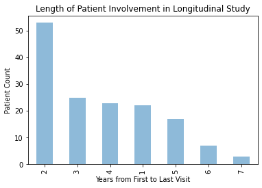

```python
# Looking at how long people were involved in the study
difference = ages["Difference"].value_counts()
difference.plot.bar(xlabel="Years from First to Last Visit", ylabel = "Patient Count", title="Length of Patient Involvement in Longitudinal Study", alpha=.5)
```

From this histogram, we can see that the longitudinal study did not cover the same number of years for each patient. The study ranged from one visit (which would have a span of 1 year here), to up to three visit spanning up to seven years. Because we are looking to build a model that is predicts risk of Alzheimer's, not age of onset, we plan to just use the data from the first visit (since the first visit had the greatest number of participants).

#### How old were people in this dataset when they had their first MRI scan for dementia?

```python
# Filtering data to get just the first visit
first_visit = df_alhz_long[df_alhz_long.Visit == 1]

#Take mean of age of filtered data
first_visit.Age.mean()
```

```
75.44666666666667
```

```python
# Take standard deviation of age of filtered data
first_visit.Age.std()
```

```
7.545421000584566
```

#### How does the number of females vs males with dementia compare in this dataset?

```
M/F
F    AxesSubplot(0.125,0.125;0.775x0.755)
M    AxesSubplot(0.125,0.125;0.775x0.755)
Name: Age, dtype: object
```

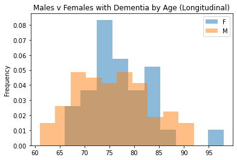

```python
# Creating new dataframe with ages in accending order
age_accending_dementia = df_alhz_long.sort_values('Age')
age_accending_dementia = age_accending_dementia[age_accending_dementia.Group == "Demented"]
age_accending_dementia.groupby("M/F").Age.plot.hist(alpha=.5, density=True, legend=True, xlabel='Age of Indv. with Dementia', title='Males v Females with Dementia by Age (Longitudinal)')
```

Compared to the male data, the female data appears to be more right-skewed. This suggests that women on average are older than men when they are affected by Alhzeimer's. We do want to account for the fact that women in general live longer than men so this could explain why diagnoses happen later on and women are more often affected by Alzheimer's. We want to look at brain differences such as pH level that differ between men and women to understand the contribution these factors may have on Alzheimer's. This is relevant to our main goal as one of the variables we are focusing on is gendered differences in Alzheimer's.

### Questions for Dataset 1 (Cross Sectional):

#### What is the average level of education (variable 'EDUC') of demented vs non-demented vs converted individuals?

```python
# Average Education level for demented individuals
df_alhz_cross[df_alhz_cross.Group == "Demented"].Educ.mean()
```

```
2.82
```

```python
# Average Education level for nondemented individuals
df_alhz_cross[df_alhz_cross.Group == "Nondemented"].Educ.mean()
```

```
3.4444444444444446
```

This is consisted with the dataframe above, showing that on average nondemented individuals had a higher education level than the demented individuals. This does appear to be on a different scale, which we address in our commentary below.

#### How are education and socioeconomic status related in this sample?

```python
df_alhz_cross["Educ"].corr(df_alhz_cross["SES"])
```

```
-0.7423610355426756
```

Similar to the longitudinal data, this statistic shows that individuals from a higher socioeconomic status were likely to recieve more education than those of lower socioeconomic statuses. The correlation is also very similar, with it being -0.74 in the cross-sectional data compared to -0.72 in the longitudinal data.

#### How old were people in this dataset when they had their MRI to scan for dementia?

```python
#Take mean of age
df_alhz_cross.Age.mean()
```

```
51.357798165137616
```

```python
# Take standard deviation of age
df_alhz_cross.Age.std()
```

```
25.269862268101562
```

The mean age of patients when they got their MRI scan was 51.3 years old, which is much younger than the previous dataset. This dataset also had a much bigger spread in regards to age, with the standard deviation of 25.3. This tells us that the cross-sectional dataset could contain cases of early onset Alzheimer's. The cross-sectional study contained over 400 individuals and studied subjects ranging between the ages of 18 and 96, whereas the longitudinal study included patients only between the ages of 60 and 96. This explains why the mean age was so different betweem the two.

#### How does the number of females vs males with dementia compare in this dataset?

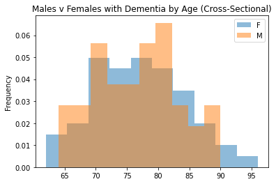

```python
# Creating new dataframe with ages in accending order
age_accending_cross = df_alhz_cross.sort_values('Age')
age_accending = age_accending_cross[age_accending_cross.Group == "Demented"]
age_accending.groupby("M/F").Age.plot.hist(alpha=.5, density=True, legend=True)
plt.title('Males v Females with Dementia by Age (Cross-Sectional)')
plt.show()
```

From this graphic, we see that females have a wider range of ages. This differs from the longtidudinal data and indicates that we have to dig deeper before drawing conclusions on our gender hypothesis.

## Dataset 2 EDA

For our milestone 2 dataset, we were interested in introducing more data related to patients with and without dementia to gain a further picture of what features may be related to cognitive decline. This dataset includes a variety of features ranging from the age of the onset of symptoms, the age of death, education levels, sex, brain weight and pH, and several cognitive test scores. Several of these same features were present in our MRI dataset, so we hope this will allow us to be able to examine these two datasets together.

### Dataset 2: Metadata

```python
 df_meta.Sex.value_counts()
```

```
Female    51
Male      33
Name: Sex, dtype: int64
```

We see that this dataframe is slightly skewed in terms of sex. There are more females than males.

```python
df_meta.Race.value_counts()
```

```
White    81
Asian     3
Name: Race, dtype: int64
```

More drastic of a skew than with sex, this dataset is almost entirely white patients, which may pose some constraints on our ability to generalize. We will keep this in mind when making any statements regarding race using this dataset, and note that this is one piece of potential missing data.

#### Distribution of Dementia by Age and Sex

```python
# Distribution of patients with and without dementia
df_meta["Cognitive Status"].value_counts()
```

```
No dementia    42
Dementia       42
Name: Cognitive Status, dtype: int64
```

```python
# ...and now grouped by sex
print("Female:")
print(df_meta[df_meta["Sex"] == "Female"]["Cognitive Status"].value_counts())
print("\nMale:")
print(df_meta[df_meta["Sex"] == "Male"]["Cognitive Status"].value_counts())
```

```
Female:
Dementia       27
No dementia    24
Name: Cognitive Status, dtype: int64

Male:
No dementia    18
Dementia       15
Name: Cognitive Status, dtype: int64
```

We see that although there are more females than males in the dataset, there is a difference of 3 between the number of donors with dementia and without dementia for both sexes. For males, there are more donors without dementia while for females there are more donors with dementia. This is information we will have to keep in mind for the rest of our EDA while comparing between sexes.

#### Brain pH for Dementia v. No dementia

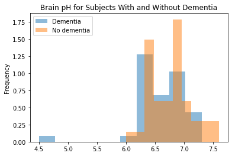

```python
df_meta.groupby("Cognitive Status")['Brain pH'].plot.hist(alpha=.5, density=True, legend=True)
plt.title('Brain pH for Subjects With and Without Dementia')
plt.xlabel=('pH')
plt.show()
```

Based on this exploratory graph, there are several observations that can be made about brain pH as it relates to dementia diagnosis. For individuals with dementia, the mode appears at individuals with pH around 6.2-6.3, whereas individuals without dementia appear to have a peak for individuals with a brain pH around 6.9. Ignoring the distinct outlier in the dementia patients, the spread of patients with and without dementia is around 1.5. However, the maximum pH for individuals without dementia is higher at around 7.6, whereas the max pH for individuals with dementia falls at around 7.2. We wanted to consider brain pH as it relates to dementia because brain pH may be a potential indicating factor for dementia, and we know that females tend to have a lower brain pH.

To dive further, we wanted to look at the differences between individuals with and without dementia and their pH levels by sex.

```
Sex
Female    AxesSubplot(0.125,0.125;0.775x0.755)
Male      AxesSubplot(0.125,0.125;0.775x0.755)
Name: Brain pH, dtype: object
```

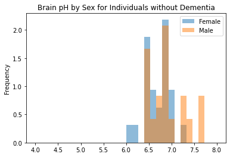

```python
df_meta_nodementia = df_meta[df_meta["Cognitive Status"] != "Dementia"]
df_meta_dementia = df_meta[df_meta["Cognitive Status"] == "Dementia"]

df_meta_nodementia.groupby("Sex")['Brain pH'].plot.hist(alpha=.5, density=True, legend=True, xlabel = "Brain pH", title = "Brain pH by Sex for Individuals without Dementia", bins=30, range=[4.0, 8.0])
```

```
Sex
Female    AxesSubplot(0.125,0.125;0.775x0.755)
Male      AxesSubplot(0.125,0.125;0.775x0.755)
Name: Brain pH, dtype: object
```

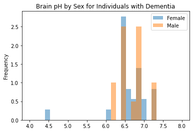

```python
# now fow dementia
df_meta_dementia.groupby("Sex")['Brain pH'].plot.hist(alpha=.5, density=True, legend=True, xlabel = "Brain pH", title = "Brain pH by Sex for Individuals with Dementia", bins=30, range=[4.0, 8.0])
```

From these two plots, it appears that brain pH is lower in the individuals with dementia. For instance, although males tend to lean towards a higher pH in both the demented and non-demented group, in the non-demented group the highest male brain pH is around 7.6 where it is around 7.3 in the demented group. Females tended to have a slightly lower brain pH in both groups, with the non-demented group having a low of about 6.0 and the demented group having a lot of around 4.4. We found this particularly interesting that females appear to have a slightly lower baseline pH compared to men and that brain pH appears to fall with dementia. At this point, we have to keep digging further to see if brain pH is a good predictor for dementia. If so, we will do more research on pH between females and males to see if baseline brain pH could contribute to the likelihood of developing dementia.

#### Examining the Relationship between Education and Dementia

One of our focuses in the previous dataset was on education and dementia, so we wanted to continue that analysis here.

```python
print("Highest Education Level")
print(df_meta["Highest level of education"].value_counts())
print("\nYears of Education")
print(df_meta["Years of education"].value_counts())
```

```
Highest Education Level
Graduate (PhD/Masters)       25
Bachelors                    22
High School                  18
Trade School/ Tech School    15
Professional                  4
Name: Highest level of education, dtype: int64

Years of Education
16    17
18    13
12    12
21    10
15     8
14     8
17     7
13     4
20     3
19     2
Name: Years of education, dtype: int64
```

All of the individuals in this dataset have had a fair amount of education (at least through high school), so we are unable to assess how extremely low levels of education may correlate with dementia. However, there is a large range in the type of education received as well as the number of years of education with a range of 9.

Average length of education for individuals with/without dementia:

```python
# Average Education level for demented individuals
print("The average number of years of education for individuals with dementia is", round(df_meta[df_meta["Cognitive Status"] == "Dementia"]["Years of education"].mean(), 2))

# Average Education level for non-demented individuals
print("The average number of years of education for individuals without dementia is", round(df_meta[df_meta["Cognitive Status"] == "No dementia"]["Years of education"].mean(), 2))
```

```
The average number of years of education for individuals with dementia is 16.62
The average number of years of education for individuals without dementia is 15.79
```

This differs from our previous dataset, where education was longer with individuals without dementia.

```python
# Average Education level for females
print("The average years of education for females is", round(df_meta[df_meta["Sex"] == "Female"]["Years of education"].mean(), 2))

# Average Education level for males
print("The average years of education for males is", round(df_meta[df_meta["Sex"] == "Male"]["Years of education"].mean(), 2))
```

```
The average years of education for females is 15.98
The average years of education for males is 16.55
```

```python
# Average Education level for females
print("The average years of education for females with dementia is", end=' ')
print(round(df_meta[(df_meta["Sex"] == "Female") & (df_meta["Cognitive Status"] == "Dementia")]["Years of education"].mean(),2))
print("The average years of education for females without dementia is", end=' ')
print(round(df_meta[(df_meta["Sex"] == "Female") & (df_meta["Cognitive Status"] == "No dementia")]["Years of education"].mean(),2))

# Average Education level for males
print("The average years of education for males with dementia is", end=' ')
print(round(df_meta[(df_meta["Sex"] == "Male") & (df_meta["Cognitive Status"] == "Dementia")]["Years of education"].mean(),2))
print("The average years of education for males without dementia is", end=' ')
print(round(df_meta[(df_meta["Sex"] == "Male") & (df_meta["Cognitive Status"] == "No dementia")]["Years of education"].mean(),2))
```

```
The average years of education for females with dementia is 16.44
The average years of education for females without dementia is 15.46
The average years of education for males with dementia is 16.93
The average years of education for males without dementia is 16.22
```

The years of education does not vary much between females and males, which will be helpful in our analysis. Therefore, when we look at education we don’t have to worry as much about the distribution of sexes.

```python
# Correlation between education and dementia

# create a numeric version of dementia column for this analysis

df_meta["cog_status_num"] = df_meta["Cognitive Status"].map({
    "Dementia": 1,
    "No dementia": 0
})


df_alhz_cross['cog_status_num'] = df_alhz_cross['Group'].map({
    'Nondemented': 0,
    'Demented': 1
})

df_alhz_long['cog_status_num'] = df_alhz_long['Group'].map({
    'Nondemented': 0,
    'Converted': 1,
    'Demented': 1
})

# correlation
print("Correlation between years of education and dementia from the meta data:")
print(df_meta["Years of education"].corr(df_meta["cog_status_num"]))
print("Correlation between years of education and dementia from oasis study...")
print("based on the cross-sectional data:", df_alhz_cross["Educ"].corr(df_alhz_cross["cog_status_num"]))
print("based on the longitudinal data:", df_alhz_long["EDUC"].corr(df_alhz_long["cog_status_num"]))
```

```
Correlation between years of education and dementia from the meta data:
0.15100381378815506
Correlation between years of education and dementia from oasis study...
based on the cross-sectional data: -0.23591049426349353
based on the longitudinal data: -0.19306010020826195
```

Once again, we see that this data may contradict our dataset from above. There appears to be a positive correlation in our new dataset between more education and the development of dementia, where it was the opposite in both datasets above. However, these correlations are still all relatively low, so we would need more data to truly determine the significance of education. We also recognize there may be some confounding factors at play here, which we want to consider when making any conclusion using our data.

```python
df_meta_dummy = pd.concat([df_meta, pd.get_dummies(df_meta["Sex"])], axis=1)
# TO DO : make a correlation matrix between certain variables and dementia
variables = ["cog_status_num",
             "Last MMSE Score",
             "Female",
             "Male",
             "Years of education"]
df_meta_dummy[variables].corr()
```

|  | cog_status_num | Last MMSE Score | Female | Male | Years of education |
| --- | --- | --- | --- | --- | --- |
| cog_status_num | 1.000000 | -0.498078 | 0.073127 | -0.073127 | 0.151004 |
| Last MMSE Score | -0.498078 | 1.000000 | -0.070174 | 0.070174 | -0.054593 |
| Female | 0.073127 | -0.070174 | 1.000000 | -1.000000 | -0.100013 |
| Male | -0.073127 | 0.070174 | -1.000000 | 1.000000 | 0.100013 |
| Years of education | 0.151004 | -0.054593 | -0.100013 | 0.100013 | 1.000000 |

From this correlation matrix, we see that none of the correlation are strong, except to themselves and male/female, which is -1 (because you must be recorded as one or the other). This is to be expected since we are examining a complex disease that even neuroscientists are unsure of its causes. We also need to remember that all of our data comes from humans, who are extremely variable in their genetic makeup, environment, and lifestyle, all of which contribute to confounding variables. However, the highest correlation appears to be between “last MMSE score” and “cog_status_num”, which is a binary column with 1 representing dementia and 0 representing no dementia. This informs us that moving forward in our prediction models, we should look at including the last MMSE score since it has a negative correlation with the cognitive status of -0.498.

#### Looking at MMSE (Mini Mental State Examination) Scores for Males/Females With/Without Dementia

The MMSE test is a means of measuring mental status and is one of the measures that might indicate dementia that is contained in both of our datasets. We wanted to attempt to compare the two datasets to see how findings differ.

Using the Metadata dataset:

```python
# Average Education level for females
print("The average MMSE for females with dementia is", end=' ')
female_d_mmse = df_meta[(df_meta["Sex"] == "Female") & (df_meta["Cognitive Status"] == "Dementia")]["Last MMSE Score"]
print(round(female_d_mmse.mean(),2))
print("The average MMSE for females without dementia is", end=' ')
female_nd_mmse = df_meta[(df_meta["Sex"] == "Female") & (df_meta["Cognitive Status"] == "No dementia")]["Last MMSE Score"]
print(round(female_nd_mmse.mean(),2))


# Average Education level for males
print("The average MMSE for males with dementia is", end=' ')
male_d_mmse = df_meta[(df_meta["Sex"] == "Male") & (df_meta["Cognitive Status"] == "Dementia")]["Last MMSE Score"]
print(round(male_d_mmse.mean(),2))
print("The average MSSE for males without dementia is", end=' ')
male_nd_mmse = df_meta[(df_meta["Sex"] == "Male") & (df_meta["Cognitive Status"] == "No dementia")]["Last MMSE Score"]
print(round(male_nd_mmse.mean(),2))
```

```
The average MMSE for females with dementia is 21.52
The average MMSE for females without dementia is 27.52
The average MMSE for males with dementia is 23.93
The average MSSE for males without dementia is 25.89
```

Using our previous MRI dataset:

```python
# Now, adding in the other datasets
df_alhz_cross["MMSE"].dropna(inplace=True)
df_alhz_long["MMSE"].dropna(inplace=True)

female_d_mmse_cross = df_alhz_cross[(df_alhz_cross["M/F"] == "F") & (df_alhz_cross["Group"] == "Demented")]["MMSE"]
female_nd_mmse_cross = df_alhz_cross[(df_alhz_cross["M/F"] == "F") & (df_alhz_cross["Group"] == "Nondemented")]["MMSE"]
female_d_mmse_long = df_alhz_long[(df_alhz_long["M/F"] == "F") & ((df_alhz_long["Group"] == "Demented") | (df_alhz_long["Group"] == "Converted"))]["MMSE"]
female_nd_mmse_long = df_alhz_long[(df_alhz_long["M/F"] == "F") & (df_alhz_long["Group"] == "Nondemented")]["MMSE"]

male_d_mmse_cross = df_alhz_cross[(df_alhz_cross["M/F"] == "M") & (df_alhz_cross["Group"] == "Demented")]["MMSE"]
male_nd_mmse_cross = df_alhz_cross[(df_alhz_cross["M/F"] == "M") & (df_alhz_cross["Group"] == "Nondemented")]["MMSE"]
male_d_mmse_long = df_alhz_long[(df_alhz_long["M/F"] == "M") & ((df_alhz_long["Group"] == "Demented") | (df_alhz_long["Group"] == "Converted"))]["MMSE"]
male_nd_mmse_long = df_alhz_long[(df_alhz_long["M/F"] == "M") & (df_alhz_long["Group"] == "Nondemented")]["MMSE"]

sum_female_d = pd.concat([female_d_mmse_long,female_d_mmse])
sum_female_d = pd.concat([sum_female_d, female_d_mmse_cross])
sum_female_nd = pd.concat([female_nd_mmse_long, female_nd_mmse])
sum_female_nd = pd.concat([sum_female_nd, female_nd_mmse_cross])
sum_male_d = pd.concat([male_d_mmse_long, male_d_mmse])
sum_male_d = pd.concat([sum_male_d, male_d_mmse_cross])
sum_male_nd = pd.concat([male_nd_mmse_long,male_nd_mmse])
sum_male_nd = pd.concat([sum_male_nd, male_nd_mmse_cross])

print("The overall average MMSE for females with dementia is", end=' ')
print(round(sum_female_d.mean(),2))
print("The overall average MMSE for females without dementia is", end=' ')
print(round(sum_female_nd.mean(),2))
print("The overall average MMSE for males with dementia is", end=' ')
print(round(sum_male_d.mean(),2))
print("The overall average MMSE for males without dementia is", end=' ')
print(round(sum_male_nd.mean(),2))
```

```
The overall average MMSE for females with dementia is 24.33
The overall average MMSE for females without dementia is 29.09
The overall average MMSE for males with dementia is 25.05
The overall average MMSE for males without dementia is 28.51
```

MMSE describes a patient’s mental state with a high score of 30 and a low of 0. Our quick dive into MMSE allowed us to see that there is a significant difference between the MMSE of individuals with and without dementia. We also were able to see that our new dataset contains individuals who had a lower score on average, since each respective mean was lower than the means of MMSE per group in the three combined datasets We will have to do a bit more research into exactly what a point in the MMSE score represents to better understand these differences.

#### Age of Diagnosis and Years of Education

```python
df_meta["Age of Dementia diagnosis"] = df_meta["Age of Dementia diagnosis"].replace(['90+'], '90')
```

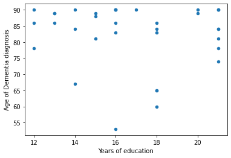

```python
# Drop the rows where there is no age of dementia diagnosis
df_temp = df_meta[df_meta["Age of Dementia diagnosis"] != 0]
df_temp.plot.scatter(x="Years of education", y="Age of Dementia diagnosis")
```

This exploratory plot suggests that, in this dataset, there does not appear to be a correlation with years of education and the age of dementia diagnosis. We have to take this with a grain of salt because a large amount of the data had to be dropped because there was no age of diagnosis recorded. However, this is definitely something worth exploring more because it plays into our question regarding the correlations between education and dementia diagnosis.

## Data Analysis and Modeling

Our initial hope when beginning this project was to see if there were correlations between gender, socioeconomic status, level of education, and the onset of Alzheimer’s or other dementias. Through our EDA, we have seen that without massive amounts of data, it may be difficult to build a predictive model since each human is so variable. However, by exploring the strongest correlations and combining them, we still hope to be able to build a working model.

Here are our ideas:

- We plan to use the gender and levels of education to predict the likelihood of developing dementia.
- We want to test if there is a statistically significant correlation between age and the onset of Alzheimer’s or other forms of dementias for males and for females.

We do want to look at addtional features beyond gender and education, even if just for exploratory purposes, to get a sense of if there are any other potential correlations to note.

### Preparation for model-building

```python
# All of the imports necessary for this modeling section
from sklearn.model_selection import cross_val_score
from sklearn.model_selection import cross_validate
from sklearn.model_selection import cross_val_predict
from sklearn.pipeline import Pipeline
from sklearn.preprocessing import StandardScaler
from sklearn.neighbors import KNeighborsClassifier
from sklearn.neighbors import KNeighborsRegressor
from sklearn.feature_extraction import DictVectorizer
from sklearn.impute import KNNImputer
from sklearn.metrics import accuracy_score, precision_score, recall_score, f1_score
import seaborn as sns
```

The first step in building our model was combining the three datasets that we have used to perform our exploratory data analysis. This involved creating limiting the dataframe that contained only features we were interested in (and that had adequate data), ensuring that the column titles matched, and ensuring that the data was structured in the same format.

```python
# Connecting the datasets

# Creating a cog status num for df_long1
df_long1['cog_status_num'] = df_alhz_long['Group'].map({
    'Nondemented': 0,
    'Converted': 1,
    'Demented': 1
})

# Creating temporary DFs with just the variables we want to look at
cols = ['Subject ID', 'cog_status_num', 'M/F','Age', 'EDUC', 'SES', 'MMSE', 'CDR', 'eTIV',
                    'nWBV', 'ASF']
temp_long = df_long1[cols]
cols = ['ID', 'cog_status_num', 'M/F', 'Age', 'Educ', 'SES', 'CDR', 'eTIV',
                    'nWBV', 'ASF']
temp_cross = df_alhz_cross[cols]
cols = ['Donor ID', 'cog_status_num', 'Sex', 'Age of onset cognitive symptoms', 'Brain pH', 'Last MMSE Score', 'Highest level of education', 'Years of education']
temp_meta = df_meta[cols]
```

```python
# Rename the column names to be consistent
# Note: EDUC_Y = Years of education, EDUC_L = level of education
temp_long = temp_long.rename(columns = {'Subject ID':'ID',
                           'M/F': 'Sex',
                           'EDUC': 'EDUC_Y'})
temp_cross = temp_cross.rename(columns = {'M/F': 'Sex',
                           'Educ': 'EDUC_L'})
temp_meta = temp_meta.rename(columns = {'Donor ID': 'ID',
                           'Last MMSE Score': 'MMSE',
                           'Highest level of education': 'EDUC_L',
                           'Years of education': 'EDUC_Y'})
```

```python
# Changing the columns to contain the same type
temp_meta['Sex'] = temp_meta['Sex'].map({
    'Male': 'M',
    'Female': 'F'
})
```

One complication that we ran into while working on combining these datasets was that the two OASIS datasets (cross-sectional and longitudinal) contained some of the same patients. To avoid skewing our results with duplicate data, we decided to use the donor IDs to drop any repeat data from the cross-sectional dataset. We needed to do this by looking at which patients matched on variables that were recorded in both datasets and excluded the ID, since participants were given different IDs in the different trials.

```python
# Append cross and long,and the drop duplicate data

alz_model_df = pd.concat([temp_long, temp_cross])
alz_model_df = alz_model_df.drop_duplicates(subset=['Age', 'MMSE', 'CDR', 'eTIV', 'nWBV', 'ASF'])
```

```python
# Appending all of them
alz_model_df = pd.concat([alz_model_df, temp_meta])

# Adding a binary sex column
alz_model_df['Sex_binary'] = alz_model_df['Sex'].map({
    'M': 1,
    'F': 0
})

# Adding a classification column for cognitive status
alz_model_df['cog_status'] = alz_model_df['cog_status_num'].map({
    1: 'Dementia',
    0: 'No dementia'
})
alz_model_df.head(5)
```

|  | ID | cog_status_num | Sex | Age | EDUC_Y | SES | MMSE | CDR | eTIV | nWBV | ASF | EDUC_L | Age of onset cognitive symptoms | Brain pH | Sex_binary | cog_status |
| --- | --- | --- | --- | --- | --- | --- | --- | --- | --- | --- | --- | --- | --- | --- | --- | --- |
| 0 | OAS2_0001 | 0.0 | M | 87.0 | 14.0 | 2.0 | 27.0 | 0.0 | 1987.0 | 0.696 | 0.883 | NaN | NaN | NaN | 1 | No dementia |
| 2 | OAS2_0002 | 1.0 | M | 75.0 | 12.0 | NaN | 23.0 | 0.5 | 1678.0 | 0.736 | 1.046 | NaN | NaN | NaN | 1 | Dementia |
| 5 | OAS2_0004 | 0.0 | F | 88.0 | 18.0 | 3.0 | 28.0 | 0.0 | 1215.0 | 0.710 | 1.444 | NaN | NaN | NaN | 0 | No dementia |
| 7 | OAS2_0005 | 0.0 | M | 80.0 | 12.0 | 4.0 | 28.0 | 0.0 | 1689.0 | 0.712 | 1.039 | NaN | NaN | NaN | 1 | No dementia |
| 10 | OAS2_0007 | 1.0 | M | 71.0 | 16.0 | NaN | 28.0 | 0.5 | 1357.0 | 0.748 | 1.293 | NaN | NaN | NaN | 1 | Dementia |

```python
# Drop rows where the cog_status_num is unknown since that is what we are predicting.
alz_model_df.dropna(subset=['cog_status'], inplace=True)
```

Just to take a look at what we're working with when thinking about a predictive model, we wanted to create a simple visualization to show the relationship between MMSE score and years of education. The green dots represent nondemented patients whereas the red represents patients with dementia. A visualization like this could be used to predict the classification of other patients based on these two features. This is not a complex model, but used more just for us to explore and play around with some graphing and visualizations.

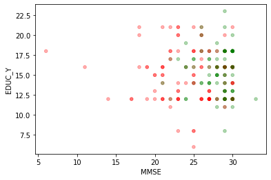

```python
alz_model_df['cog_status'].value_counts()

#Plot training data with color representing cognitive status
colors = alz_model_df['cog_status'].map({
    "Dementia": "red",
    "No dementia": "green"
})

alz_model_df.plot.scatter(
    x = "MMSE", y = "EDUC_Y", c=colors,
    alpha=.3
)
```

To start the process of building a model, we wanted to take an initial look at the correlations of our combined dataframe. We used these correlation coefficients to inform us on potential variables to be using as features in our model.

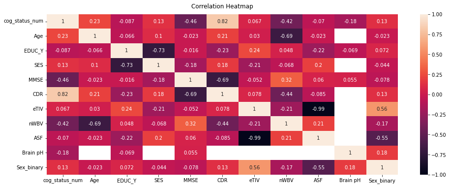

```python
plt.figure(figsize=(16, 6))
heatmap = sns.heatmap(alz_model_df.corr(), vmin=-1, vmax=1, annot=True)
heatmap.set_title('Correlation Heatmap', fontdict={'fontsize':12}, pad=12);
```

At this point, some of the stronger correlations we noted was between nWBV and Age and between SES and EDUC_Y.

nWBV refers to the normalized whole brain volume. In this correlation matrix, it appears that there is a strong negative correlation in the volume and patient age, indicating that as patients age, brain volume also declines. This is interesting to note because maybe excelerated decline of nWBV could be a potential sign of dementia that we could include in our model. In other words, nondemented individuals may have a slower rate of brain atrophy whereas patients with Alzheimer's may have accelerated atrophy worth considering as a predictive feature.

In terms of SES and EDUC_Y, we were initially surprised to see a relatively strong negative correlation. However, upon closer investigation, we realized SES is measured on a 1-5 scale, where a measure of 1 indicates higher socioeconomic status. Therefore, as SES increases, EDUC_Y would be expected to decrease, as individuals of a lower socieconomic status are not surprisingly less likely to have high levels of education.

This is not to say that none of the other correlations are worth noting, but just at this simple level we noticed a few potential areas worth including in our models, which we wanted to further investigate.

To begin, we wanted to build a simple model with the features we've been working with while also imputing values for our missing data.

```python
# define features
features = ["Sex_binary", "EDUC_Y", "SES", "MMSE", "eTIV", "nWBV", "ASF", "Brain pH"]

nan = np.nan
X = alz_model_df[features]
imputer = KNNImputer(n_neighbors=2, weights="uniform")
X = imputer.fit_transform(X)
df_X = pd.DataFrame(X, columns = features)

# Define training data
#X_train_dict = dict(enumerate(X.flatten(), 1))
X_train_dict = df_X.to_dict(orient="records")
y_train = alz_model_df["cog_status_num"]

# Dummy encoding
vec = DictVectorizer(sparse=False)
vec.fit(X_train_dict)
X_train = vec.transform(X_train_dict)
#X_new = vec.transform(X_new_dict)

# Standardize the data
scaler = StandardScaler()
scaler.fit(X_train)
X_train_sc = scaler.transform(X_train)

# Fit the 9-nearest neighbors model
model = KNeighborsClassifier(n_neighbors=9)
model.fit(X_train_sc, y_train)
```

```
KNeighborsClassifier(n_neighbors=9)
```

```python
y_train_pred = model.predict(X_train_sc)
accuracy = accuracy_score(y_train, y_train_pred)
precision = precision_score(y_train, y_train_pred, pos_label=1)
recall = recall_score(y_train, y_train_pred, pos_label=1)
f1_score =  2*((precision*recall)/(precision+recall))
print("accuracy:", accuracy, "\nprecision:", precision, "\nrecall:", recall, "\nf1:", f1_score)
```

```
accuracy: 0.7270788912579957
precision: 0.7110091743119266
recall: 0.7045454545454546
f1: 0.7077625570776256
```

Our goal with this first model and performance metrics was to test our method of imputation. We tried a few differnt ways, but found that we consistently got the best results using the KNN imputer. While we recognize that imputing data may throw off some of our performance metrics, we ultimately decided that was our only option due to limited open-source data. This first model does not use cross validation or the optimal number of neighbors, which we select later on.

#### K Value Selection:

We wanted to get a sense of what value for k is best for an improved KNN-prediction model.

```python
def model_testing_k(features, Y_var, scoring_type, k):
    # define the training data
    X_train_dict = alz_model_df[features].to_dict(orient="records")
    y_train = Y_var

    # convert categorical variables to dummy variables
    vec = DictVectorizer(sparse=False)
    vec.fit(X_train_dict)
    X_train = vec.transform(X_train_dict)

    # specify the pipeline
    nan = np.nan
    imputer = KNNImputer(n_neighbors=2, weights="uniform")
    scaler = StandardScaler()
    model = KNeighborsRegressor(n_neighbors=k)


    # Create pipeline
    pipeline = Pipeline([
        ("imputer", imputer),
        ("scaler", scaler),
        ("model", model)
    ])

    # calculate evaluation metric using cross validation
    return  cross_val_score(pipeline, X_train, y_train,
                    cv=10, scoring=scoring_type)
```

```python
features = ["Sex_binary", "EDUC_Y", "SES", "MMSE", "eTIV", "nWBV", "ASF", "Brain pH"]
X_train_dict = alz_model_df[features].to_dict(orient="records")
y_train = alz_model_df["cog_status_num"]

vec = DictVectorizer(sparse=False)
vec.fit(X_train_dict)
X_train_sc = vec.transform(X_train_dict)

nan = np.nan
imputer = KNNImputer(n_neighbors=2, weights="uniform")
X_train_sc = imputer.fit_transform(X_train_sc)

nmses = []
k_opts = [i for i in range(1, 51, 1)]
for k in k_opts:
    nmse = -np.mean(model_testing_k(features, y_train, 'neg_mean_squared_error', k))
    nmses.append(nmse)
```

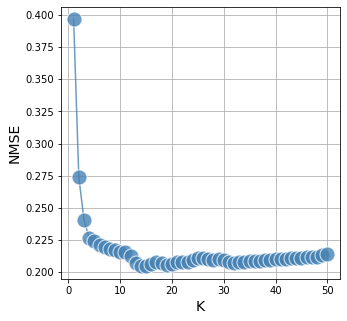

```python
fig, ax = plt.subplots(1,1,figsize=(5,5))

ax.plot(k_opts, nmses, marker="o", linestyle="-",markersize=15, color="steelblue", markeredgecolor="white", alpha=0.8)

ax.set_ylabel("NMSE", fontsize=14)
ax.set_xlabel("K", fontsize=14)
plt.grid()
plt.show()
```

```python
nmses_series = pd.Series(nmses)
min_nmse = nmses_series.min()
idxmin_nmse = nmses_series.idxmin()
(min_nmse, idxmin_nmse)
```

```
(0.20452670429874079, 13)
```

#### Feature Selection:

When building a better version of our model, we wanted to be sure that we were building a model around factors that had the best predictive potential. We wanted to test out modeling with a different selection of features and investigate how our different values of accuracy, precision, recall, and F1 changed based on the different features we utilized. This function allowed us to put in a different selection of features and output the different measurement values.

```python
# feature testing using multiple scoring metrics
def feature_selection(features):
    X_train_dict = alz_model_df[features].to_dict(orient="records")
    y_train = alz_model_df["cog_status"]

    # convert categorical variables to dummy variables
    vec = DictVectorizer(sparse=False)
    vec.fit(X_train_dict)
    X_train = vec.transform(X_train_dict)

    # specify the pipeline
    model = KNeighborsClassifier(n_neighbors=13)

    # Create pipeline
    pipeline = Pipeline([
        ("imputer", imputer),
        ("scaler", scaler),
        ("model", model)
    ])

    scoring = {'acc': 'accuracy',
           'prec': 'precision',
           'rec': 'recall',
            'f1': 'f1'}


    is_demented_train = (y_train == "Dementia")
    cv_results = cross_validate(pipeline, X_train, is_demented_train,
                cv=10, scoring=scoring)

    array_scores = np.mean(list(cv_results.values()),1)[2:]
    print("Accuracy: ", array_scores[0], "\nPrecision: ", array_scores[1], "\nRecall: ", array_scores[2], "\nF1 Score: ", array_scores[3])
```

Looking at using all features:

```python
features1 = ["Sex_binary", "EDUC_Y", "SES", "MMSE", "eTIV", "nWBV", "ASF", "Brain pH"]
feature_selection(features1)
```

```
Accuracy:  0.6629509713228492
Precision:  0.6536152543109065
Recall:  0.6363636363636364
F1 Score:  0.6343387875302768
```

Excluding SSE:

```python
features2 = ["Sex_binary", "EDUC_Y", "MMSE", "eTIV", "nWBV", "ASF", "Brain pH"]
feature_selection(features2)
```

```
Accuracy:  0.6629972247918594
Precision:  0.6425536728389052
Recall:  0.6590909090909091
F1 Score:  0.6411227449736051
```

Excluding Sex_binary:

```python
features3 = ["EDUC_Y", "SES", "MMSE", "eTIV", "nWBV", "ASF", "Brain pH"]
feature_selection(features3)
```

```
Accuracy:  0.6779833487511564
Precision:  0.6823222034748625
Recall:  0.65
F1 Score:  0.6406647699073049
```

Excluding Sex_binary and SSE:

```python
features4 = ["EDUC_Y", "MMSE", "eTIV", "nWBV", "ASF", "Brain pH"]
feature_selection(features4)
```

```
Accuracy:  0.6609158186864015
Precision:  0.6674306735521128
Recall:  0.6318181818181817
F1 Score:  0.6247648950358135
```

Excluding Sex_binary and nWBV:

```python
features5 = ["EDUC_Y", "SES", "MMSE", "eTIV", "ASF", "Brain pH"]
feature_selection(features5)
```

```
Accuracy:  0.5842738205365403
Precision:  0.550197143499775
Recall:  0.4818181818181818
F1 Score:  0.5041567449740483
```

Excluding Sex_binary and MMSE:

```python
features6 = ["EDUC_Y", "SES", "eTIV", "nWBV", "ASF", "Brain pH"]
feature_selection(features6)
```

```
Accuracy:  0.5945420906567993
Precision:  0.5762638092638093
Recall:  0.5727272727272728
F1 Score:  0.5617140823649163
```

Excluding Sex_binary and EDUC_Y:

```python
features7 = ["SES", "MMSE", "eTIV", "nWBV", "ASF", "Brain pH"]
feature_selection(features7)
```

```
Accuracy:  0.6672987974098057
Precision:  0.6576358826358828
Recall:  0.6454545454545454
F1 Score:  0.6430863293014604
```

Excluding Sex_binary, EDUC_Y, and SES:

```python
features8 = ["MMSE", "eTIV", "nWBV", "ASF", "Brain pH"]
feature_selection(features8)
```

```
Accuracy:  0.6800647548566141
Precision:  0.6660677577782841
Recall:  0.6590909090909091
F1 Score:  0.6536202532339482
```

While we were initially really interested in looking at the impacts of sex and education as primary predictive features, through a lot of our exploratory analysis and feature selection work, we recognize that several other values regarding brain volumetrics and other data may have stronger potential to act as predictive features. This is an interesting finding despite the uncertainty in some of our findings and our lack of expertise, because this does suggest that some of these other factors may be a dead-end for research and may suggest that scientists focus more on the other brain predictive features such as pH, nWBV, and eTIV, as well as the ability for scores such as MMSE to come in handy in early prediction of dementia.

In an improved version of our model, we want to build our model using the features we have selected as well as our selection for K. We did play around with trying to use mean imputation as well as trying to use IterativeImputer from Sci-kit learn (which is still experimental), however both of these approaches resulted in a decrease in our accuracy, recall, precision, and F1, so we decided to stick with KNNImputer. We also played around with n_neighbors to see the impact, but also decided to stick with our original imputation method. We recognize that there may be other ways to improve our imputation for the missing data, but we decided that for the purposes of this project we will stick with this.

```python
# define features
features = ["EDUC_Y", "SES", "MMSE", "eTIV", "nWBV", "ASF", "Brain pH"]

nan = np.nan
X = alz_model_df[features]
imputer = KNNImputer(n_neighbors=2, weights="uniform")
X = imputer.fit_transform(X)
df_X = pd.DataFrame(X, columns = features)


# Define training data
X_train_dict = df_X.to_dict(orient="records")
y_train = alz_model_df["cog_status_num"]

# Dummy encoding
vec = DictVectorizer(sparse=False)
vec.fit(X_train_dict)
X_train = vec.transform(X_train_dict)

# Standardize the data
scaler = StandardScaler()
scaler.fit(X_train)
X_train_sc = scaler.transform(X_train)

# Fit the 13-nearest neighbors model
model = KNeighborsClassifier(n_neighbors=13)
model.fit(X_train_sc, y_train)
```

```
KNeighborsClassifier(n_neighbors=13)
```

```python
y_train_pred = model.predict(X_train_sc)
accuracy = accuracy_score(y_train, y_train_pred)
precision = precision_score(y_train, y_train_pred, pos_label=1)
recall = recall_score(y_train, y_train_pred, pos_label=1)
f1_score =  2*((precision*recall)/(precision+recall))
print("accuracy:", accuracy, "\nprecision:", precision, "\nrecall:", recall, "\nf1:", f1_score)
```

```
accuracy: 0.746268656716418
precision: 0.7186147186147186
recall: 0.7545454545454545
f1: 0.7361419068736141
```

We saw that playing with our K-value and selected features, we were able to slightly improve our model's accuracy, precision, recall, and f1 score. This model does not use cross validation, so these numbers represent the training performance, not the test. To see the test performance, we can run our selection from above:

```python
finalfeatures = ["EDUC_Y", "SES", "MMSE", "eTIV", "nWBV", "ASF", "Brain pH"]
feature_selection(finalfeatures)
```

```
Accuracy:  0.6779833487511564
Precision:  0.6823222034748625
Recall:  0.65
F1 Score:  0.6406647699073049
```

As is expected, our test scores are lower than the training. However, despite a large margin for error, we chose this as our final model due to the many confounding variables that go into ALzheimer's and our limited access to data.

## Insights and Final Thoughts

Going into our project, we were both initially really interested in more of the social and demographic patient features in terms of their correlation with the onset of dementia symptoms and diagnosis. Through our exploratory research and modeling, we did notice that there is probably a lot more potential for research to focus on the more specific cognitive brain data in order to understand how brain changes may have the potential to be used for early diagnosis and, in the future, potentially for prevention and therapy purposes. This project was a very difficult one at the offset because even the most informed scientists are still struggling to truly understand this disease and means of predicting diagnosis. However, we did find that our analysis presented us with some really interesting conclusions and prompted us to look into features that we were not initially as interested in exploring. The real value of our conclusions was to suggest where future research may be headed and to understand some methods for where more complex modeling may be used in the study of Alzheimer's going forward.

To improve upon our current model, we would recommend:

- Gaining access to larger and more complete datasets
- Using age within the model (this was not possible for us due to ambiguity with "90+")
- Integrating datasets that examine more healthy brains at different ages to understand the effects of aging on the brain

#### References

Alzheimer’s disease and healthy aging indicators: Cognitive decline | Chronic disease and health promotion data & indicators. (n.d.).https://chronicdata.cdc.gov/Healthy-Aging/Alzheimer-s-Disease-and-Healthy-Aging-Indicators-C/jhd5-u276

Buckner, R. L., Head, D., Parker, J., Fotenos, A. F., Marcus, D. S., Morris, J. C., et al (2004). A unified approach for morphometric and functional data analysis in young, old, and demented adults using automated atlas-based head size normalization: Reliability and validation against manual measurement of total intracranial volume. Neuroimage, 23, 724–738.

Daniel S. Marcus, Anthony F. Fotenos, John G. Csernansky, John C. Morris, Randy L. Buckner; Open Access Series of Imaging Studies: Longitudinal MRI Data in Nondemented and Demented Older Adults. J Cogn Neurosci 2010; 22 (12): 2677–2684. https://direct.mit.edu/jocn/article/22/12/2677/4983/Open-Access-Series-of-Imaging-Studies-Longitudinal

Folstein, M. F., Folstein, S. E., & McHugh, P. R. (1975). “Mini-mental state”. A practical method for grading the cognitive state of patients for the clinician. Journal of Psychiatric Research, 12, 189–198.

Fotenos, A. F., Snyder, A. Z., Girton, L. E., Morris, J. C., & Buckner, R. L. (2005). Normative estimates of cross-sectional and longitudinal brain volume decline in aging and AD. Neurology, 64, 1032–1039.

Hollingshead, A. (1957). Two factor index of social position. New Haven, CT: Yale University Press.

Kavitha, C., Mani, V., Srividhya, S. R., Khalaf, O. I., & Tavera Romero, C. A. (2022). Early-stage alzheimer’s disease prediction using machine learning models. Frontiers in Public Health, 10. https://www.frontiersin.org/articles/10.3389/fpubh.2022.853294

Marcus, D. S., Wang, T. H., Parker, J., Csernansky, J. G., Morris, J. C., & Buckner, R. L. (2007). Open access series of imaging studies (Oasis): Cross-sectional mri data in young, middle aged, nondemented, and demented older adults. Journal of Cognitive Neuroscience, 19(9), 1498–1507. https://doi.org/10.1162/jocn.2007.19.9.1498

Morris, J. C. (1993). The Clinical Dementia Rating (CDR): Current version and scoring rules. Neurology, 43, 2412–2414.

Mri and alzheimers. (n.d.). https://www.kaggle.com/datasets/jboysen/mri-and-alzheimers

Seattle alzheimer's disease brain cell atlas: Donor metadata. https://portal.brain-map.org/explore/seattle-alzheimers-disease/seattle-alzheimers-disease-brain-cell-atlas-download?edit&language=en

Back to Top